# Analysis on data aquired

# Build dataframe for Alg

Starting with the dataframe foreach country that we used for make the analisys we build a new dataframe with more features and selecting only the features available foreach country.

## New temporal features

We want to give a stress on **WHEN** the our record are beloging to, in this way we suppose to give more tools to our alg for identify and discriminate the data using time, following features will be added:

- day_zero, when the country has reached 100 cases of infected
- delta_day_zero, the days delta between record date and country day_zero
- week_year, number of the week record date belonging to
- day_year, number of the day record date belonging to
- day_week, number of the weekday record date belonging to
- day_week_sin, since day_week is ciclic value we need this trasformation for compute distance between record
- day_week_cos, since day_week is ciclic value we need this trasformation for compute distance between record
- lockdown_meter TODO

```python
mgc['week_year'] = mgc.index.strftime("%W")
mgc['day_year'] = mgc.index.strftime("%j")
mgc['day_week'] = mgc.index.strftime("%w")

mgc
```

| date | country | daily_cases | daily_dead | daily_test | delta_day_zero | population | total_cases | total_dead | total_test | week_year | day_year | day_week |
| --- | --- | --- | --- | --- | --- | --- | --- | --- | --- | --- | --- | --- |
| 2020-01-20 | south_korea | 1 | 0 | 0 | -31 | 51269183 | 1 | 0 | 1 | 03 | 020 | 1 |
| 2020-01-21 | south_korea | 0 | 0 | 0 | -30 | 51269183 | 1 | 0 | 1 | 03 | 021 | 2 |
| 2020-01-22 | south_korea | 0 | 0 | 3 | -29 | 51269183 | 1 | 0 | 4 | 03 | 022 | 3 |
| 2020-01-23 | south_korea | 0 | 0 | 18 | -28 | 51269183 | 1 | 0 | 22 | 03 | 023 | 4 |
| 2020-01-24 | south_korea | 1 | 0 | 5 | -27 | 51269183 | 2 | 0 | 27 | 03 | 024 | 5 |
| ... | ... | ... | ... | ... | ... | ... | ... | ... | ... | ... | ... | ... |
| 2020-04-19 | italy | 3047 | 433 | 50708 | 55 | 60461828 | 178972 | 23660 | 1356541 | 15 | 110 | 0 |
| 2020-04-20 | italy | 2256 | 454 | 41483 | 56 | 60461828 | 181228 | 24114 | 1398024 | 16 | 111 | 1 |
| 2020-04-21 | italy | 2729 | 534 | 52126 | 57 | 60461828 | 183957 | 24648 | 1450150 | 16 | 112 | 2 |
| 2020-04-22 | italy | 3370 | 437 | 63101 | 58 | 60461828 | 187327 | 25085 | 1513251 | 16 | 113 | 3 |
| 2020-04-23 | italy | 2646 | 464 | 66658 | 59 | 60461828 | 189973 | 25549 | 1579909 | 16 | 114 | 4 |

434 rows × 12 columns

```python
mgc['day_week_sin'] = np.sin(2 * np.pi * mgc['day_week'].astype(int)/6.0)
mgc['day_week_cos'] = np.cos(2 * np.pi * mgc['day_week'].astype(int)/6.0)
```

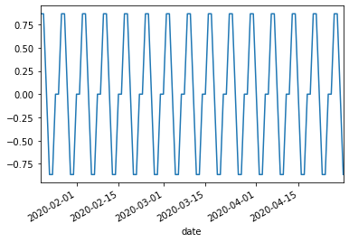

```python
ax = mgc['day_week_sin'].plot()
```

## Country related features

Since we are dealing with data belonging from some different state we'll add some features about the trait of each country, then we compute some other using country data and epidemic data of that country, following features will be added:

- population, country population
- total_test_pc, total_test / population
- daily_test_pc, daily_test / population
- total_cases_pc, total_cases / population
- daily_cases_pc, daily_cases / population
- total_dead_pc, total_dead / population
- daily_dead_pc, daily_dead / population
- lethality, total_dead / total_cases
- GDP_pc, country GDP / population

```python
col_pc = ["total_test_pc","daily_test_pc","total_cases_pc","daily_cases_pc", "total_dead_pc","daily_dead_pc","lethality","GDP_pc"]
mgc = mgc.reindex(columns=mgc.columns.tolist() + col_pc)

for i in range(len(mgc.index)):
    pop = mgc.iloc[i, mgc.columns.get_loc("population")]
    mgc.iloc[i, mgc.columns.get_loc("total_test_pc")] = mgc.iloc[i, mgc.columns.get_loc("total_test")]/pop
    mgc.iloc[i, mgc.columns.get_loc("daily_test_pc")] = mgc.iloc[i, mgc.columns.get_loc("daily_test")]/pop
    mgc.iloc[i, mgc.columns.get_loc("total_cases_pc")] = mgc.iloc[i, mgc.columns.get_loc("total_cases")]/pop
    mgc.iloc[i, mgc.columns.get_loc("daily_cases_pc")] = mgc.iloc[i, mgc.columns.get_loc("daily_cases")]/pop
    mgc.iloc[i, mgc.columns.get_loc("total_dead_pc")] = mgc.iloc[i, mgc.columns.get_loc("total_dead")]/pop
    mgc.iloc[i, mgc.columns.get_loc("daily_dead_pc")] = mgc.iloc[i, mgc.columns.get_loc("daily_dead")]/pop
    if mgc.iloc[i, mgc.columns.get_loc("total_dead")] > 0:
        mgc.iloc[i, mgc.columns.get_loc("lethality")] = mgc.iloc[i, mgc.columns.get_loc("total_dead")] / mgc.iloc[i, mgc.columns.get_loc("total_cases")]
    else:
        mgc.iloc[i, mgc.columns.get_loc("lethality")] = 0
    mgc.iloc[i, mgc.columns.get_loc("GDP_pc")] = (gdp[gdp.index.values == mgc.iloc[i, mgc.columns.get_loc("country")]]/pop).values[0][0]
```

```python
mgc = mgc[mgc["delta_day_zero"] >= 0]
```

```python
days_by_country = {}
for state in states:
    days_by_country[state] = int(mgc[mgc["country"]==state].count().country)

print(days_by_country)
```

```
{'italy': 60, 'india': 47, 'usa': 52, 'united_kingdom': 56, 'south_korea': 61}
```

# TEST select data between day 0 and day N

```python
#mgc = mgc[mgc["delta_day_zero"] >= 0]
mgc = mgc[mgc["delta_day_zero"] <= 31]
mgc
```

| date | country | daily_cases | daily_dead | daily_test | delta_day_zero | population | total_cases | total_dead | total_test | week_year | ... | day_week_sin | day_week_cos | total_test_pc | daily_test_pc | total_cases_pc | daily_cases_pc | total_dead_pc | daily_dead_pc | lethality | GDP_pc |
| --- | --- | --- | --- | --- | --- | --- | --- | --- | --- | --- | --- | --- | --- | --- | --- | --- | --- | --- | --- | --- | --- |
| 2020-02-20 | south_korea | 53 | 1 | 2029 | 0 | 51269183 | 104 | 1 | 13202 | 07 | ... | -8.660254e-01 | -0.5 | 0.000258 | 0.000040 | 0.000002 | 0.000001 | 1.950489e-08 | 1.950489e-08 | 0.009615 | 31586.688268 |
| 2020-02-21 | south_korea | 100 | 1 | 3198 | 1 | 51269183 | 204 | 2 | 16400 | 07 | ... | -8.660254e-01 | 0.5 | 0.000320 | 0.000062 | 0.000004 | 0.000002 | 3.900979e-08 | 1.950489e-08 | 0.009804 | 31586.688268 |
| 2020-02-22 | south_korea | 229 | 0 | 5186 | 2 | 51269183 | 433 | 2 | 21586 | 07 | ... | -2.449294e-16 | 1.0 | 0.000421 | 0.000101 | 0.000008 | 0.000004 | 3.900979e-08 | 0.000000e+00 | 0.004619 | 31586.688268 |
| 2020-02-23 | south_korea | 169 | 4 | 4593 | 3 | 51269183 | 602 | 6 | 26179 | 07 | ... | 0.000000e+00 | 1.0 | 0.000511 | 0.000090 | 0.000012 | 0.000003 | 1.170294e-07 | 7.801958e-08 | 0.009967 | 31586.688268 |
| 2020-02-24 | south_korea | 231 | 2 | 6577 | 4 | 51269183 | 833 | 8 | 32756 | 08 | ... | 8.660254e-01 | 0.5 | 0.000639 | 0.000128 | 0.000016 | 0.000005 | 1.560392e-07 | 3.900979e-08 | 0.009604 | 31586.688268 |
| ... | ... | ... | ... | ... | ... | ... | ... | ... | ... | ... | ... | ... | ... | ... | ... | ... | ... | ... | ... | ... | ... |
| 2020-03-22 | italy | 5560 | 651 | 25180 | 27 | 60461828 | 59138 | 5476 | 258402 | 11 | ... | 0.000000e+00 | 1.0 | 0.004274 | 0.000416 | 0.000978 | 0.000092 | 9.056954e-05 | 1.076712e-05 | 0.092597 | 34465.783264 |
| 2020-03-23 | italy | 4789 | 601 | 17066 | 28 | 60461828 | 63927 | 6077 | 275468 | 12 | ... | 8.660254e-01 | 0.5 | 0.004556 | 0.000282 | 0.001057 | 0.000079 | 1.005097e-04 | 9.940156e-06 | 0.095062 | 34465.783264 |
| 2020-03-24 | italy | 5249 | 743 | 21496 | 29 | 60461828 | 69176 | 6820 | 296964 | 12 | ... | 8.660254e-01 | -0.5 | 0.004912 | 0.000356 | 0.001144 | 0.000087 | 1.127984e-04 | 1.228875e-05 | 0.098589 | 34465.783264 |
| 2020-03-25 | italy | 5210 | 683 | 27481 | 30 | 60461828 | 74386 | 7503 | 324445 | 12 | ... | 1.224647e-16 | -1.0 | 0.005366 | 0.000455 | 0.001230 | 0.000086 | 1.240948e-04 | 1.129638e-05 | 0.100866 | 34465.783264 |
| 2020-03-26 | italy | 6153 | 662 | 36615 | 31 | 60461828 | 80539 | 8165 | 361060 | 12 | ... | -8.660254e-01 | -0.5 | 0.005972 | 0.000606 | 0.001332 | 0.000102 | 1.350439e-04 | 1.094906e-05 | 0.101379 | 34465.783264 |

160 rows × 22 columns

## Level of lockdown

```python
for i in range(len(mgc.index)):
    country = mgc.iloc[i, mgc.columns.get_loc("country")]
    date = mgc.index[i].to_pydatetime()
    if(date < level_1_of_lockdown[country]):
        mgc.iloc[i, mgc.columns.get_loc("level_of_lockdown")] = 0
    elif(level_2_of_lockdown[country] is not None):
        if(date < level_2_of_lockdown[country]):
            mgc.iloc[i, mgc.columns.get_loc("level_of_lockdown")] = 1
        else:
            mgc.iloc[i, mgc.columns.get_loc("level_of_lockdown")] = 2
    else:
        mgc.iloc[i, mgc.columns.get_loc("level_of_lockdown")] = 1
```

## School closure

```python
for i in range(len(mgc.index)):
    country = mgc.iloc[i, mgc.columns.get_loc("country")]
    date = mgc.index[i].to_pydatetime()
    if(date < school_closure[country]):
        mgc.iloc[i, mgc.columns.get_loc("school_closure")] = 0
    else:
        mgc.iloc[i, mgc.columns.get_loc("school_closure")] = 1
```

## Dummizzation of categorical feature

```python
mgc = pd.get_dummies(mgc,
                   columns=['country', 'level_of_lockdown', 'school_closure'])
info = pd.get_dummies(info,
                   columns=['continent', 'political_spectrum'])
```

## Prescaling of features values

```python
from sklearn import preprocessing

temp_mgc = mgc.copy()

#temp_mgc = temp_mgc.reset_index()
#temp_mgc.drop("date",axis=1,inplace=True)
#temp_mgc.drop("day_year",axis=1,inplace=True)
transf = preprocessing.MinMaxScaler().fit(temp_mgc)
temp_mgc = transf.transform(temp_mgc)
temp_mgc = pd.DataFrame(temp_mgc)

temp_mgc
```

|  | 0 | 1 | 2 | 3 | 4 | 5 | 6 | 7 | 8 | 9 | ... | 21 | 22 | 23 | 24 | 25 | 26 | 27 | 28 | 29 | 30 |
| --- | --- | --- | --- | --- | --- | --- | --- | --- | --- | --- | --- | --- | --- | --- | --- | --- | --- | --- | --- | --- | --- |
| 0 | 0.001462 | 0.000739 | 0.011097 | 0.000000 | 0.000000 | 0.000000 | 0.000119 | 0.007275 | 0.000 | 0.000000 | ... | 0.0 | 0.0 | 1.0 | 0.0 | 0.0 | 1.0 | 0.0 | 0.0 | 1.0 | 0.0 |
| 1 | 0.002864 | 0.000739 | 0.017490 | 0.032258 | 0.000000 | 0.000324 | 0.000239 | 0.009193 | 0.000 | 0.018182 | ... | 0.0 | 0.0 | 1.0 | 0.0 | 0.0 | 1.0 | 0.0 | 0.0 | 1.0 | 0.0 |
| 2 | 0.006714 | 0.000000 | 0.028363 | 0.064516 | 0.000000 | 0.001066 | 0.000239 | 0.012304 | 0.000 | 0.036364 | ... | 0.0 | 0.0 | 1.0 | 0.0 | 0.0 | 1.0 | 0.0 | 0.0 | 1.0 | 0.0 |
| 3 | 0.004923 | 0.002956 | 0.025120 | 0.096774 | 0.000000 | 0.001613 | 0.000716 | 0.015058 | 0.000 | 0.054545 | ... | 0.0 | 0.0 | 1.0 | 0.0 | 0.0 | 1.0 | 0.0 | 0.0 | 1.0 | 0.0 |
| 4 | 0.006773 | 0.001478 | 0.035971 | 0.129032 | 0.000000 | 0.002362 | 0.000955 | 0.019003 | 0.125 | 0.072727 | ... | 0.0 | 0.0 | 1.0 | 0.0 | 0.0 | 1.0 | 0.0 | 0.0 | 1.0 | 0.0 |
| ... | ... | ... | ... | ... | ... | ... | ... | ... | ... | ... | ... | ... | ... | ... | ... | ... | ... | ... | ... | ... | ... |
| 155 | 0.165781 | 0.481153 | 0.137714 | 0.870968 | 0.006918 | 0.191233 | 0.653539 | 0.154332 | 0.500 | 0.563636 | ... | 0.0 | 1.0 | 0.0 | 0.0 | 0.0 | 0.0 | 0.0 | 1.0 | 0.0 | 1.0 |
| 156 | 0.142776 | 0.444198 | 0.093337 | 0.903226 | 0.006918 | 0.206746 | 0.725266 | 0.164567 | 0.625 | 0.581818 | ... | 0.0 | 1.0 | 0.0 | 0.0 | 0.0 | 0.0 | 0.0 | 1.0 | 0.0 | 1.0 |
| 157 | 0.156502 | 0.549150 | 0.117565 | 0.935484 | 0.006918 | 0.223750 | 0.813940 | 0.177459 | 0.625 | 0.600000 | ... | 0.0 | 1.0 | 0.0 | 0.0 | 0.0 | 0.0 | 0.0 | 1.0 | 0.0 | 1.0 |
| 158 | 0.155338 | 0.504804 | 0.150298 | 0.967742 | 0.006918 | 0.240627 | 0.895453 | 0.193940 | 0.625 | 0.618182 | ... | 0.0 | 1.0 | 0.0 | 0.0 | 0.0 | 0.0 | 0.0 | 1.0 | 0.0 | 1.0 |
| 159 | 0.183476 | 0.489283 | 0.200254 | 1.000000 | 0.006918 | 0.260559 | 0.974460 | 0.215900 | 0.625 | 0.636364 | ... | 0.0 | 1.0 | 0.0 | 0.0 | 0.0 | 0.0 | 0.0 | 1.0 | 0.0 | 1.0 |

160 rows × 31 columns

# Clustering

```python
columns = ['delta_day_zero', 'total_test_pc',
       'daily_test_pc', 'total_cases_pc', 'daily_cases_pc', 'total_dead_pc',
       'daily_dead_pc', 'GDP_pc']
temp_mgc2 = temp_mgc.loc[:, columns]
temp_mgc2.columns
```

```
Index(['delta_day_zero', 'total_test_pc', 'daily_test_pc', 'total_cases_pc',
       'daily_cases_pc', 'total_dead_pc', 'daily_dead_pc', 'GDP_pc'],
      dtype='object')
```

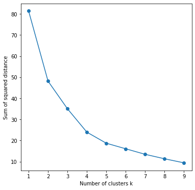

```python
plt.figure(figsize=(6, 6))
plt.plot(list_k, inertia, '-o')
plt.xlabel(r'Number of clusters k')
plt.ylabel('Sum of squared distance')
```

```
For n_clusters = 2 The average silhouette_score is : 0.45307422777200423
For n_clusters = 3 The average silhouette_score is : 0.3844095403646867
For n_clusters = 4 The average silhouette_score is : 0.4183068597032296
For n_clusters = 5 The average silhouette_score is : 0.45299457629216544
For n_clusters = 6 The average silhouette_score is : 0.42258149228277464
For n_clusters = 7 The average silhouette_score is : 0.43596010714291233
For n_clusters = 8 The average silhouette_score is : 0.4141398357526393
For n_clusters = 9 The average silhouette_score is : 0.4539420127017271
For n_clusters = 10 The average silhouette_score is : 0.44135597381506686
```

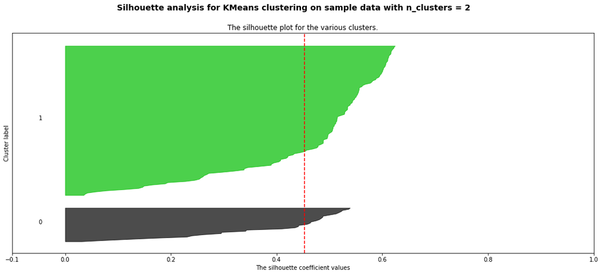

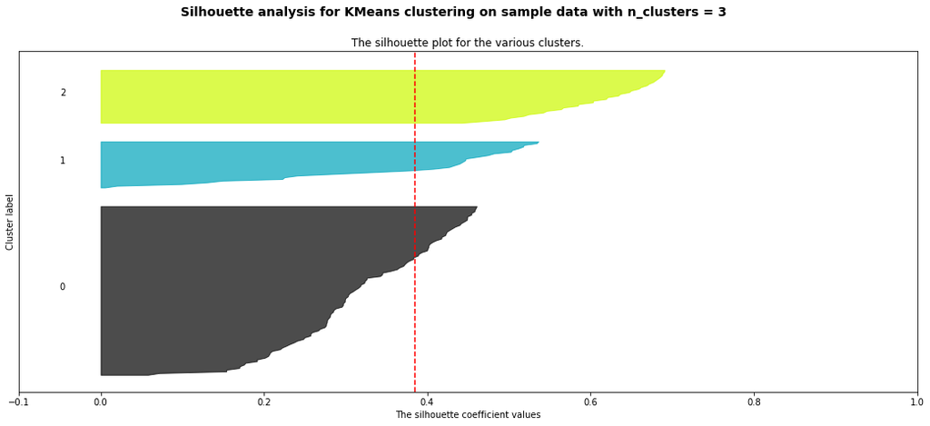

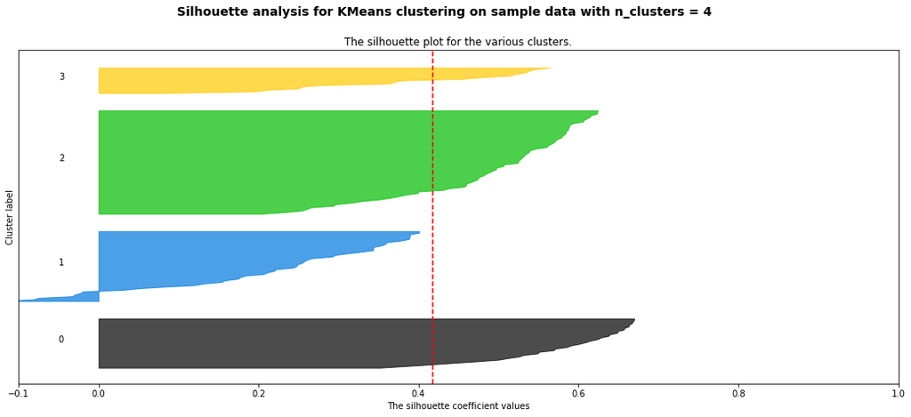

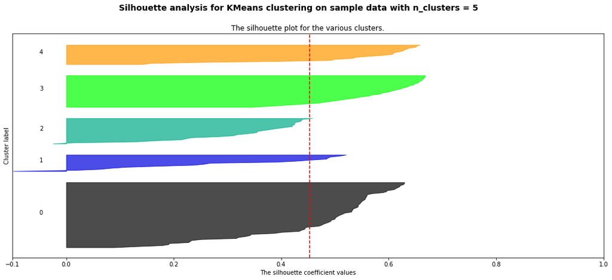

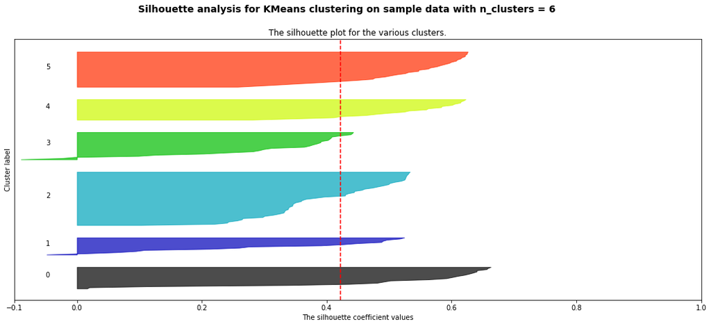

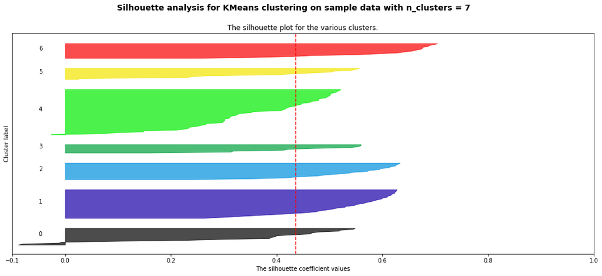

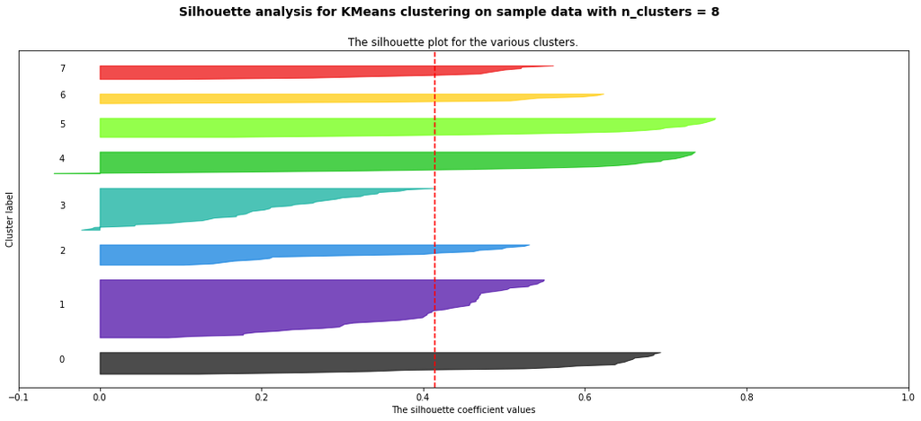

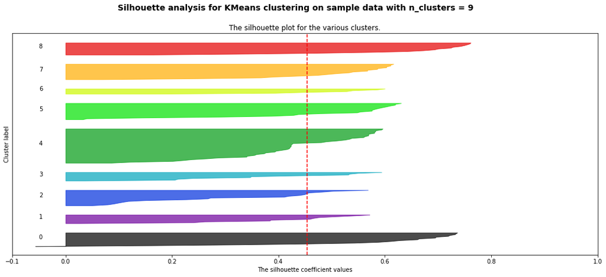

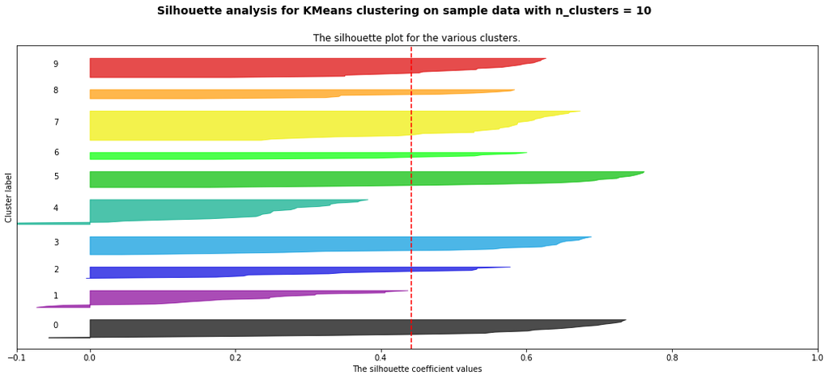

```python
from sklearn.metrics import silhouette_samples, silhouette_score
import matplotlib.cm as cm


range_n_clusters = [2, 3, 4, 5, 6, 7, 8, 9, 10]

for n_clusters in range_n_clusters:
    # Create a subplot with 1 row and 2 columns
    fig, (ax1) = plt.subplots()
    fig.set_size_inches(18, 7)

    # The 1st subplot is the silhouette plot
    # The silhouette coefficient can range from -1, 1 but in this example all
    # lie within [-0.1, 1]
    ax1.set_xlim([-0.1, 1])
    # The (n_clusters+1)*10 is for inserting blank space between silhouette
    # plots of individual clusters, to demarcate them clearly.
    ax1.set_ylim([0, len(temp_mgc2) + (n_clusters + 1) * 10])

    # Initialize the clusterer with n_clusters value and a random generator
    # seed of 10 for reproducibility.
    clusterer = KMeans(n_clusters=n_clusters, random_state=10)
    cluster_labels = clusterer.fit_predict(temp_mgc2)

    # The silhouette_score gives the average value for all the samples.
    # This gives a perspective into the density and separation of the formed
    # clusters
    silhouette_avg = silhouette_score(temp_mgc2, cluster_labels)
    print("For n_clusters =", n_clusters,
          "The average silhouette_score is :", silhouette_avg)

    # Compute the silhouette scores for each sample
    sample_silhouette_values = silhouette_samples(temp_mgc2, cluster_labels)

    y_lower = 10
    for i in range(n_clusters):
        # Aggregate the silhouette scores for samples belonging to
        # cluster i, and sort them
        ith_cluster_silhouette_values = \
            sample_silhouette_values[cluster_labels == i]

        ith_cluster_silhouette_values.sort()

        size_cluster_i = ith_cluster_silhouette_values.shape[0]
        y_upper = y_lower + size_cluster_i

        color = cm.nipy_spectral(float(i) / n_clusters)
        ax1.fill_betweenx(np.arange(y_lower, y_upper),
                          0, ith_cluster_silhouette_values,
                          facecolor=color, edgecolor=color, alpha=0.7)

        # Label the silhouette plots with their cluster numbers at the middle
        ax1.text(-0.05, y_lower + 0.5 * size_cluster_i, str(i))

        # Compute the new y_lower for next plot
        y_lower = y_upper + 10  # 10 for the 0 samples

    ax1.set_title("The silhouette plot for the various clusters.")
    ax1.set_xlabel("The silhouette coefficient values")
    ax1.set_ylabel("Cluster label")

    # The vertical line for average silhouette score of all the values
    ax1.axvline(x=silhouette_avg, color="red", linestyle="--")

    ax1.set_yticks([])  # Clear the yaxis labels / ticks
    ax1.set_xticks([-0.1, 0, 0.2, 0.4, 0.6, 0.8, 1])

    plt.suptitle(("Silhouette analysis for KMeans clustering on sample data "
                  "with n_clusters = %d" % n_clusters),
                 fontsize=14, fontweight='bold')

plt.show()
```

```python
kmeans_test = KMeans(n_clusters=3)
kmeans_test.fit(temp_mgc2)
temp_mgc["labels"] = kmeans_test.labels_
```

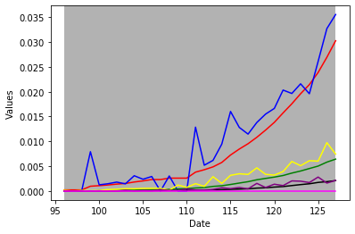

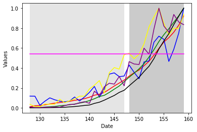

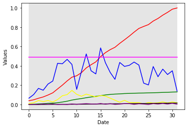

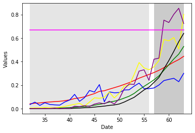

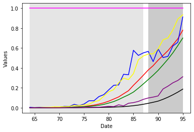

```python
import matplotlib.dates as mdates

for state in temp_states:
    plt.plot(state.index, state.total_test_pc, 'red')
    plt.plot(state.index, state.daily_test_pc, 'blue')
    plt.plot(state.index, state.total_cases_pc, 'green')
    plt.plot(state.index, state.daily_cases_pc, 'yellow')
    plt.plot(state.index, state.total_dead_pc, 'black')
    plt.plot(state.index, state.daily_dead_pc, 'purple')
    #plt.plot(state.index, state.lethality, 'gray')
    plt.plot(state.index, state.GDP_pc, 'fuchsia')


    temp1 = state[state["labels"] == 0]
    temp2 = state[state["labels"] == 1]
    temp3 = state[state["labels"] == 2]

    try:
        min1 = temp1.index.values.min()
        max1 = temp1.index.values.max()
        plt.axvspan(min1, max1, facecolor='0.8', alpha=0.5)
    except:
        print("")

    try:
        min2 = temp2.index.values.min()
        max2 = temp2.index.values.max()
        plt.axvspan(min2, max2, facecolor='0.6', alpha=0.5)
    except:
        print("")

    try:
        min3 = temp3.index.values.min()
        max3 = temp3.index.values.max()
        plt.axvspan(min3, max3, facecolor='0.4', alpha=0.5)
    except:
        print("")


    plt.xlabel('Date')
    plt.ylabel('Values')
    plt.show()
```

```python
columns = ['total_test_pc',
       'daily_test_pc', 'total_cases_pc', 'daily_cases_pc', 'total_dead_pc',
       'daily_dead_pc', 'level_of_lockdown_0.0', 'level_of_lockdown_1.0',
       'level_of_lockdown_2.0' ]

temp_mgc2 = temp_mgc.loc[:, columns]
temp_mgc2.columns
```

```
Index(['total_test_pc', 'daily_test_pc', 'total_cases_pc', 'daily_cases_pc',
       'total_dead_pc', 'daily_dead_pc', 'level_of_lockdown_0.0',
       'level_of_lockdown_1.0', 'level_of_lockdown_2.0'],
      dtype='object')
```

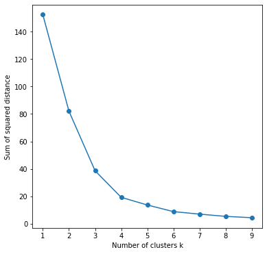

```python
plt.figure(figsize=(6, 6))
plt.plot(list_k, inertia, '-o')
plt.xlabel(r'Number of clusters k')
plt.ylabel('Sum of squared distance')
```

```
For n_clusters = 2 The average silhouette_score is : 0.497342047286568
For n_clusters = 3 The average silhouette_score is : 0.6789613128080735
For n_clusters = 4 The average silhouette_score is : 0.6889866304946028
For n_clusters = 5 The average silhouette_score is : 0.6637238132566674
For n_clusters = 6 The average silhouette_score is : 0.6476964128051703
For n_clusters = 7 The average silhouette_score is : 0.6359422780679465
For n_clusters = 8 The average silhouette_score is : 0.6580186166475824
For n_clusters = 9 The average silhouette_score is : 0.6425617378705082
For n_clusters = 10 The average silhouette_score is : 0.6463404082759776
```

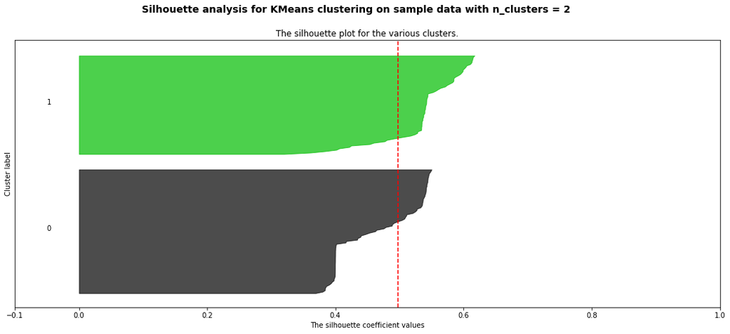

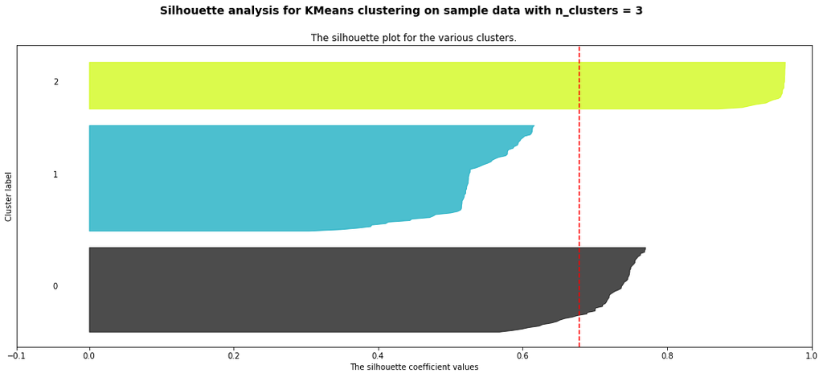

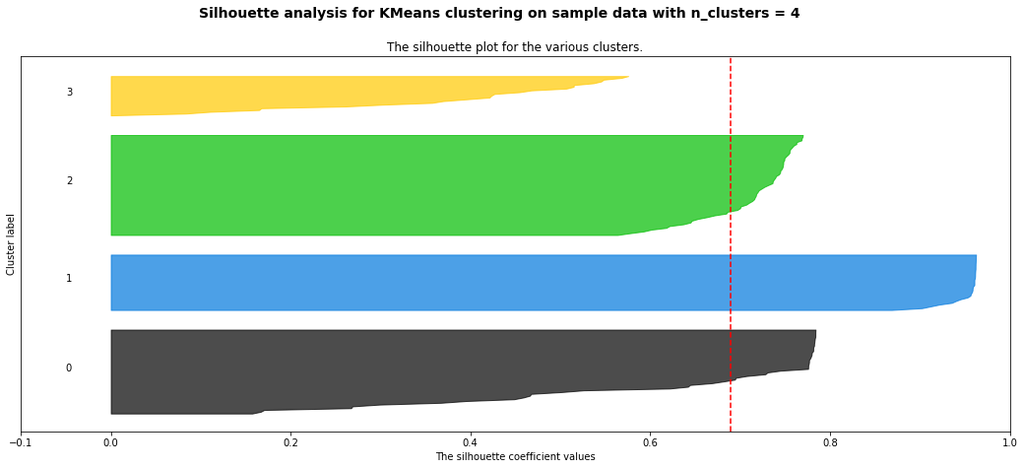

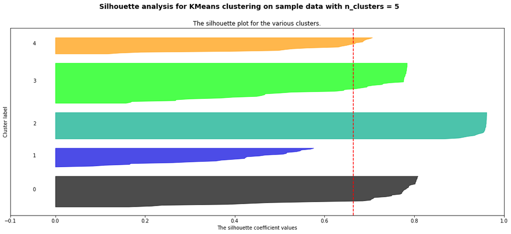

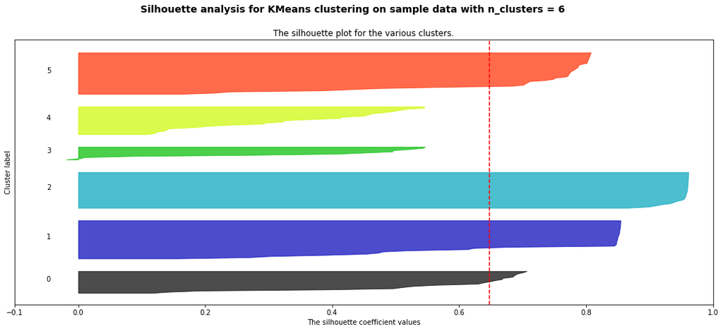

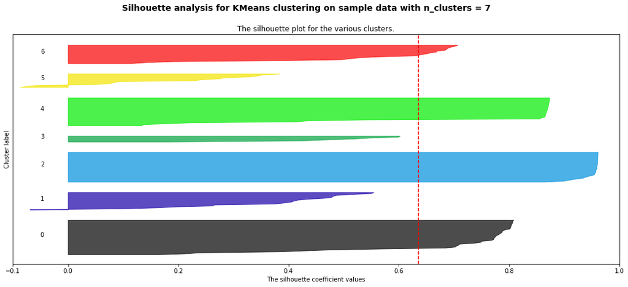

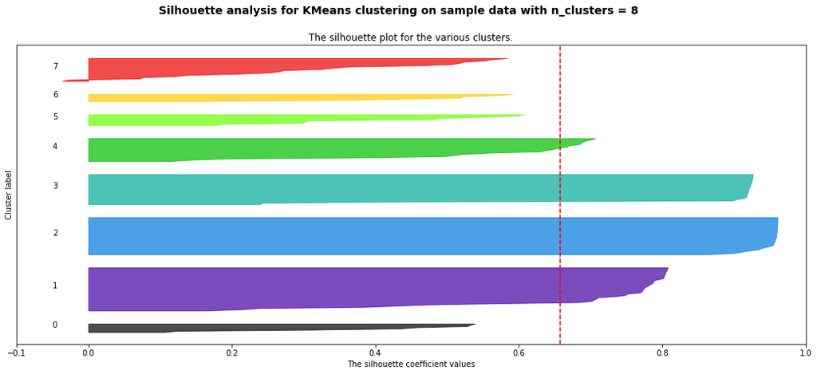

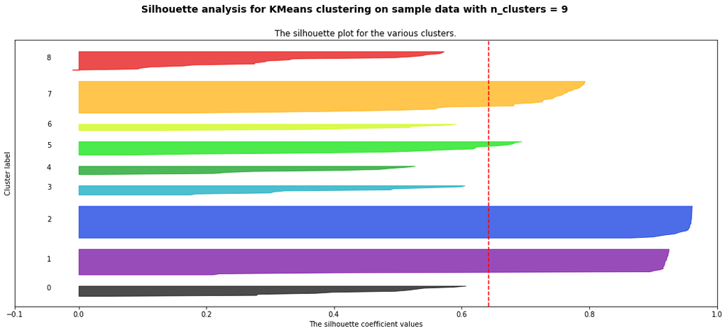

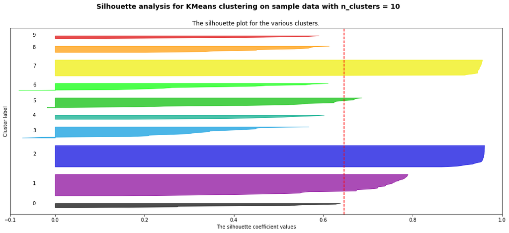

```python
range_n_clusters = [2, 3, 4, 5, 6, 7, 8, 9, 10]

for n_clusters in range_n_clusters:
    # Create a subplot with 1 row and 2 columns
    fig, (ax1) = plt.subplots()
    fig.set_size_inches(18, 7)

    # The 1st subplot is the silhouette plot
    # The silhouette coefficient can range from -1, 1 but in this example all
    # lie within [-0.1, 1]
    ax1.set_xlim([-0.1, 1])
    # The (n_clusters+1)*10 is for inserting blank space between silhouette
    # plots of individual clusters, to demarcate them clearly.
    ax1.set_ylim([0, len(temp_mgc2) + (n_clusters + 1) * 10])

    # Initialize the clusterer with n_clusters value and a random generator
    # seed of 10 for reproducibility.
    clusterer = KMeans(n_clusters=n_clusters, random_state=10)
    cluster_labels = clusterer.fit_predict(temp_mgc2)

    # The silhouette_score gives the average value for all the samples.
    # This gives a perspective into the density and separation of the formed
    # clusters
    silhouette_avg = silhouette_score(temp_mgc2, cluster_labels)
    print("For n_clusters =", n_clusters,
          "The average silhouette_score is :", silhouette_avg)

    # Compute the silhouette scores for each sample
    sample_silhouette_values = silhouette_samples(temp_mgc2, cluster_labels)

    y_lower = 10
    for i in range(n_clusters):
        # Aggregate the silhouette scores for samples belonging to
        # cluster i, and sort them
        ith_cluster_silhouette_values = \
            sample_silhouette_values[cluster_labels == i]

        ith_cluster_silhouette_values.sort()

        size_cluster_i = ith_cluster_silhouette_values.shape[0]
        y_upper = y_lower + size_cluster_i

        color = cm.nipy_spectral(float(i) / n_clusters)
        ax1.fill_betweenx(np.arange(y_lower, y_upper),
                          0, ith_cluster_silhouette_values,
                          facecolor=color, edgecolor=color, alpha=0.7)

        # Label the silhouette plots with their cluster numbers at the middle
        ax1.text(-0.05, y_lower + 0.5 * size_cluster_i, str(i))

        # Compute the new y_lower for next plot
        y_lower = y_upper + 10  # 10 for the 0 samples

    ax1.set_title("The silhouette plot for the various clusters.")
    ax1.set_xlabel("The silhouette coefficient values")
    ax1.set_ylabel("Cluster label")

    # The vertical line for average silhouette score of all the values
    ax1.axvline(x=silhouette_avg, color="red", linestyle="--")

    ax1.set_yticks([])  # Clear the yaxis labels / ticks
    ax1.set_xticks([-0.1, 0, 0.2, 0.4, 0.6, 0.8, 1])

    plt.suptitle(("Silhouette analysis for KMeans clustering on sample data "
                  "with n_clusters = %d" % n_clusters),
                 fontsize=14, fontweight='bold')

plt.show()
```

```python
kmeans_test = KMeans(n_clusters=4)
kmeans_test.fit(temp_mgc2)
temp_mgc["labels"] = kmeans_test.labels_
```

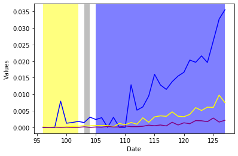

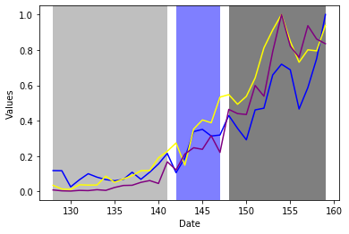

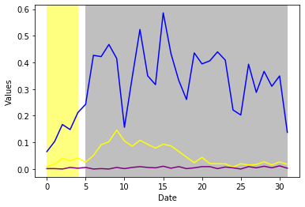

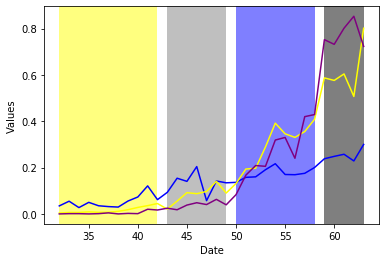

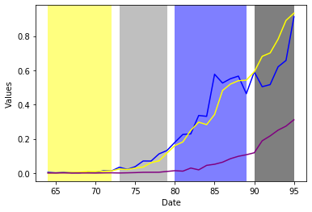

```python
import matplotlib.dates as mdates

for state in temp_states:
    '''
    if(state[state["country_india"] == 1.0]): title = "India"
    elif(state[state["country_italy"] == 1.0]): title = "Italy"
    elif(state[state["country_south_korea"] == 1.0]): title = "SK"
    elif(state[state["country_united_kingdom"] == 1.0]): title = "Uk"
    elif(state[state["country_usa"] == 1.0]): title = "Usa"
    '''
    state = temp_states[state]
    plt.plot(state.index, state.daily_test_pc, 'blue')
    plt.plot(state.index, state.daily_cases_pc, 'yellow')
    plt.plot(state.index, state.daily_dead_pc, 'purple')
    #plt.plot(state.index, state.lethality, 'gray')


    temp1 = state[state["labels"] == 0]
    temp2 = state[state["labels"] == 1]
    temp3 = state[state["labels"] == 2]
    temp4 = state[state["labels"] == 3]
    temp5 = state[state["labels"] == 4]
    temp6 = state[state["labels"] == 5]
    temp7 = state[state["labels"] == 6]
    temp8 = state[state["labels"] == 7]

    try:
        min1 = temp1.index.values.min()
        max1 = temp1.index.values.max()
        plt.axvspan(min1, max1, facecolor='gray', alpha=0.5)
    except:
        print("")

    try:
        min2 = temp2.index.values.min()
        max2 = temp2.index.values.max()
        plt.axvspan(min2, max2, facecolor='blue', alpha=0.5)
    except:
        print("")

    try:
        min3 = temp3.index.values.min()
        max3 = temp3.index.values.max()
        plt.axvspan(min3, max3, facecolor='yellow', alpha=0.5)
    except:
        print("")

    try:
        min4 = temp4.index.values.min()
        max4 = temp4.index.values.max()
        plt.axvspan(min4, max4, facecolor='black', alpha=0.5)
    except:
        print("")

    try:
        min5 = temp5.index.values.min()
        max5 = temp5.index.values.max()
        plt.axvspan(min5, max5, facecolor='red', alpha=0.5)
    except:
        print("")

    try:
        min6 = temp6.index.values.min()
        max6 = temp6.index.values.max()
        plt.axvspan(min6, max6, facecolor='green', alpha=0.5)
    except:
        print("")

    try:
        min7 = temp7.index.values.min()
        max7 = temp7.index.values.max()
        plt.axvspan(min7, max7, facecolor='purple', alpha=0.5)
    except:
        print("")

    try:
        min8 = temp8.index.values.min()
        max8 = temp8.index.values.max()
        plt.axvspan(min8, max8, facecolor='brown', alpha=0.5)
    except:
        print("")

    plt.xlabel('Date')
    plt.ylabel('Values')
    #plt.title(title)
    plt.show()
```

```python
info
```

| country | democracy_score | GPD_pc | median_age | continent_america | continent_asia | continent_europe | political_spectrum_centre-left | political_spectrum_centre-right |
| --- | --- | --- | --- | --- | --- | --- | --- | --- |
| italy | 7.52 | 31586.67 | 45.5 | 0 | 0 | 1 | 1 | 0 |
| india | 6.90 | 1970.09 | 28.1 | 0 | 1 | 0 | 0 | 1 |
| south_korea | 8.00 | 34465.79 | 41.8 | 0 | 1 | 0 | 1 | 0 |
| united_kingdom | 8.52 | 42060.17 | 40.5 | 0 | 0 | 1 | 0 | 1 |
| usa | 7.96 | 62067.00 | 38.1 | 1 | 0 | 0 | 0 | 1 |

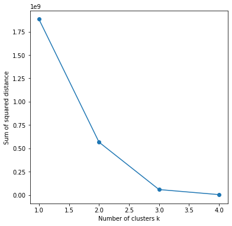

```python
plt.figure(figsize=(6, 6))
plt.plot(list_k, inertia, '-o')
plt.xlabel(r'Number of clusters k')
plt.ylabel('Sum of squared distance')
```

```
For n_clusters = 2 The average silhouette_score is : 0.4732799021583068
For n_clusters = 3 The average silhouette_score is : 0.42666066644705725
For n_clusters = 4 The average silhouette_score is : 0.2691983630554011
```

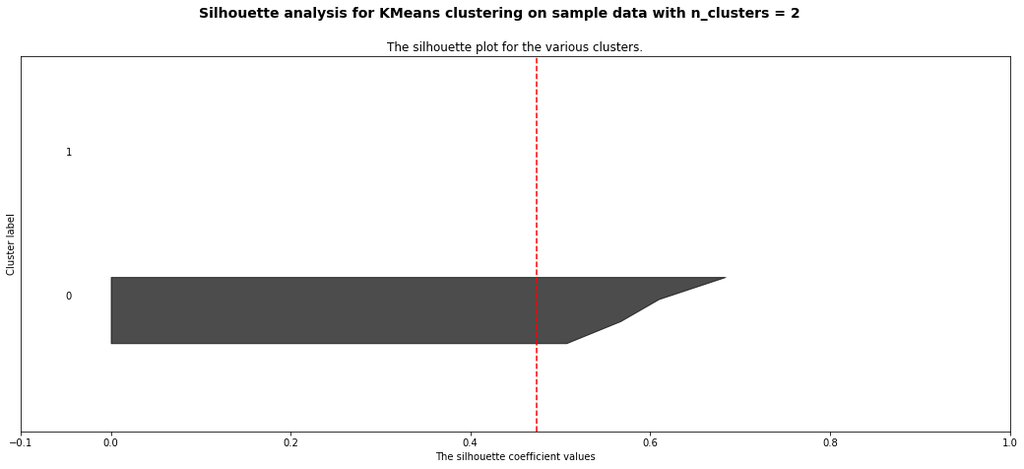

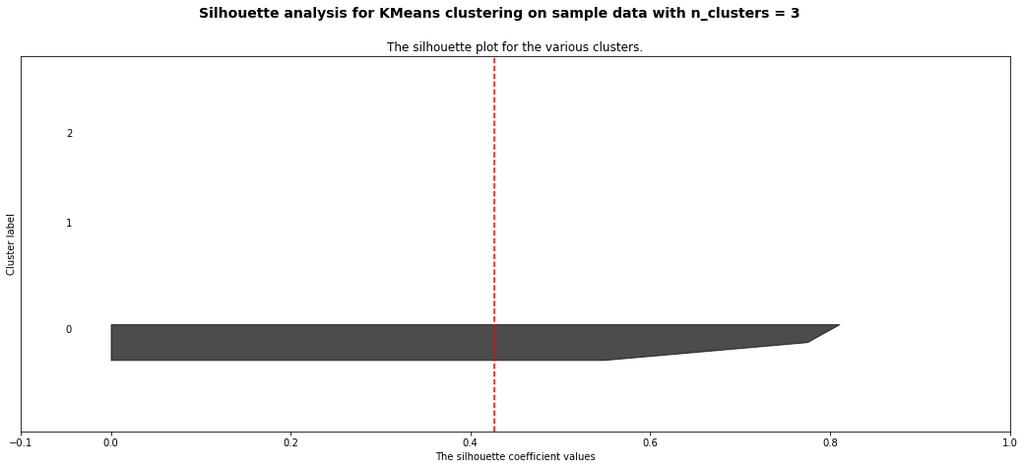

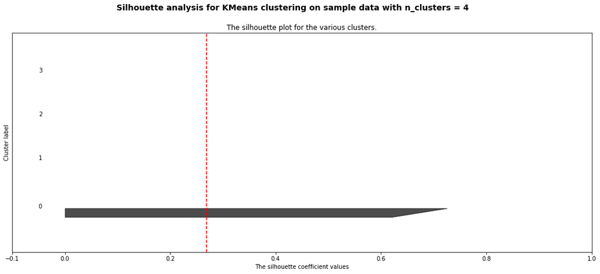

```python
range_n_clusters = [2, 3, 4]

for n_clusters in range_n_clusters:
    # Create a subplot with 1 row and 2 columns
    fig, (ax1) = plt.subplots()
    fig.set_size_inches(18, 7)

    # The 1st subplot is the silhouette plot
    # The silhouette coefficient can range from -1, 1 but in this example all
    # lie within [-0.1, 1]
    ax1.set_xlim([-0.1, 1])
    # The (n_clusters+1)*10 is for inserting blank space between silhouette
    # plots of individual clusters, to demarcate them clearly.
    ax1.set_ylim([0, len(info) + (n_clusters + 1) * 4])

    # Initialize the clusterer with n_clusters value and a random generator
    # seed of 10 for reproducibility.
    clusterer = KMeans(n_clusters=n_clusters, random_state=4)
    cluster_labels = clusterer.fit_predict(info)

    # The silhouette_score gives the average value for all the samples.
    # This gives a perspective into the density and separation of the formed
    # clusters
    silhouette_avg = silhouette_score(info, cluster_labels)
    print("For n_clusters =", n_clusters,
          "The average silhouette_score is :", silhouette_avg)

    # Compute the silhouette scores for each sample
    sample_silhouette_values = silhouette_samples(info, cluster_labels)

    y_lower = 4
    for i in range(n_clusters):
        # Aggregate the silhouette scores for samples belonging to
        # cluster i, and sort them
        ith_cluster_silhouette_values = \
            sample_silhouette_values[cluster_labels == i]

        ith_cluster_silhouette_values.sort()

        size_cluster_i = ith_cluster_silhouette_values.shape[0]
        y_upper = y_lower + size_cluster_i

        color = cm.nipy_spectral(float(i) / n_clusters)
        ax1.fill_betweenx(np.arange(y_lower, y_upper),
                          0, ith_cluster_silhouette_values,
                          facecolor=color, edgecolor=color, alpha=0.7)

        # Label the silhouette plots with their cluster numbers at the middle
        ax1.text(-0.05, y_lower + 0.5 * size_cluster_i, str(i))

        # Compute the new y_lower for next plot
        y_lower = y_upper + 4  # 10 for the 0 samples

    ax1.set_title("The silhouette plot for the various clusters.")
    ax1.set_xlabel("The silhouette coefficient values")
    ax1.set_ylabel("Cluster label")

    # The vertical line for average silhouette score of all the values
    ax1.axvline(x=silhouette_avg, color="red", linestyle="--")

    ax1.set_yticks([])  # Clear the yaxis labels / ticks
    ax1.set_xticks([-0.1, 0, 0.2, 0.4, 0.6, 0.8, 1])

    plt.suptitle(("Silhouette analysis for KMeans clustering on sample data "
                  "with n_clusters = %d" % n_clusters),
                 fontsize=14, fontweight='bold')

plt.show()
```

```python
kmeans_country = KMeans(n_clusters=3)
kmeans_country.fit(info)
info["country_cluster"] = kmeans_country.labels_
```

```python
last_final_ultimate_mgc = pd.DataFrame()
last_final_ultimate_mgc_info = pd.DataFrame()
#columns=["day_phase0","day_phase1","day_phase2","day_phase3","country_label"]
for state in temp_states:
    datarow = {"country_label": int(info[info.index == state].country_cluster.values), "country":state}
    state = temp_states[state]
    for i in range(0,4):
        datarow["day_phase"+str(i)] = len(state[state["labels"] == i])
    last_final_ultimate_mgc_info = last_final_ultimate_mgc_info.append(datarow,ignore_index=True)

last_final_ultimate_mgc = last_final_ultimate_mgc_info.drop("country",axis=1)
```

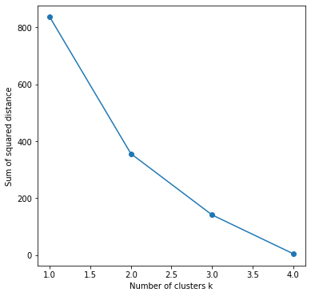

```python
plt.figure(figsize=(6, 6))
plt.plot(list_k, inertia, '-o')
plt.xlabel(r'Number of clusters k')
plt.ylabel('Sum of squared distance')
```

```
For n_clusters = 2 The average silhouette_score is : 0.3348196289411523
For n_clusters = 3 The average silhouette_score is : 0.22919801317732844
For n_clusters = 4 The average silhouette_score is : 0.3117407195948136
```

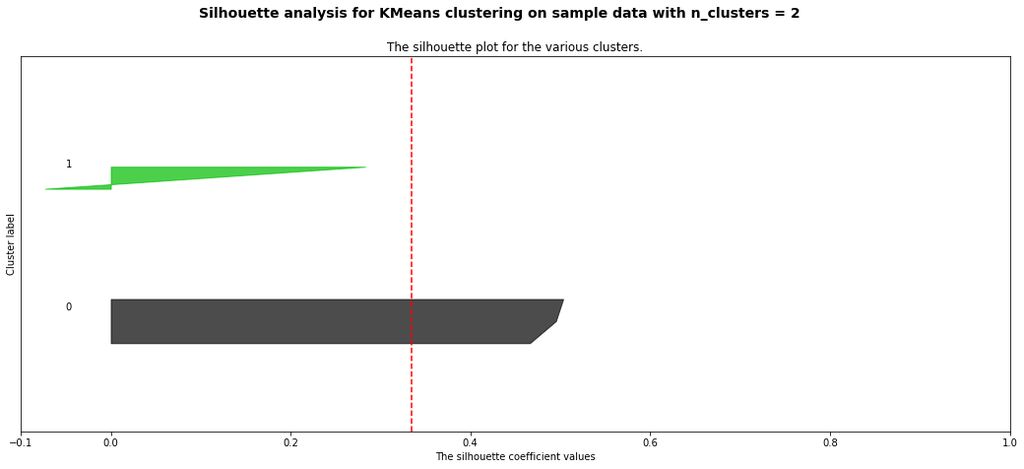

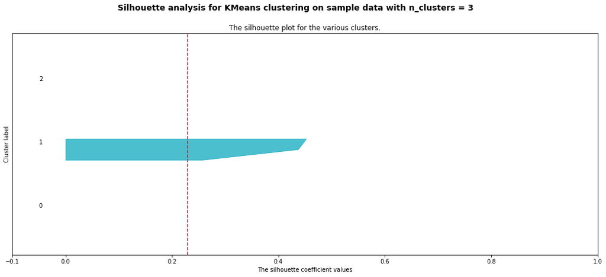

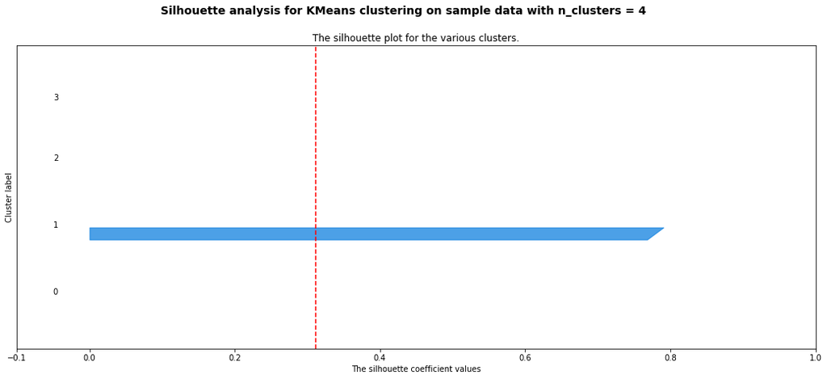

```python
range_n_clusters = [2, 3, 4]

for n_clusters in range_n_clusters:
    # Create a subplot with 1 row and 2 columns
    fig, (ax1) = plt.subplots()
    fig.set_size_inches(18, 7)

    # The 1st subplot is the silhouette plot
    # The silhouette coefficient can range from -1, 1 but in this example all
    # lie within [-0.1, 1]
    ax1.set_xlim([-0.1, 1])
    # The (n_clusters+1)*10 is for inserting blank space between silhouette
    # plots of individual clusters, to demarcate them clearly.
    ax1.set_ylim([0, len(last_final_ultimate_mgc) + (n_clusters + 1) * 4])

    # Initialize the clusterer with n_clusters value and a random generator
    # seed of 10 for reproducibility.
    clusterer = KMeans(n_clusters=n_clusters, random_state=4)
    cluster_labels = clusterer.fit_predict(last_final_ultimate_mgc)

    # The silhouette_score gives the average value for all the samples.
    # This gives a perspective into the density and separation of the formed
    # clusters
    silhouette_avg = silhouette_score(last_final_ultimate_mgc, cluster_labels)
    print("For n_clusters =", n_clusters,
          "The average silhouette_score is :", silhouette_avg)

    # Compute the silhouette scores for each sample
    sample_silhouette_values = silhouette_samples(last_final_ultimate_mgc, cluster_labels)

    y_lower = 4
    for i in range(n_clusters):
        # Aggregate the silhouette scores for samples belonging to
        # cluster i, and sort them
        ith_cluster_silhouette_values = \
            sample_silhouette_values[cluster_labels == i]

        ith_cluster_silhouette_values.sort()

        size_cluster_i = ith_cluster_silhouette_values.shape[0]
        y_upper = y_lower + size_cluster_i

        color = cm.nipy_spectral(float(i) / n_clusters)
        ax1.fill_betweenx(np.arange(y_lower, y_upper),
                          0, ith_cluster_silhouette_values,
                          facecolor=color, edgecolor=color, alpha=0.7)

        # Label the silhouette plots with their cluster numbers at the middle
        ax1.text(-0.05, y_lower + 0.5 * size_cluster_i, str(i))

        # Compute the new y_lower for next plot
        y_lower = y_upper + 4  # 10 for the 0 samples

    ax1.set_title("The silhouette plot for the various clusters.")
    ax1.set_xlabel("The silhouette coefficient values")
    ax1.set_ylabel("Cluster label")

    # The vertical line for average silhouette score of all the values
    ax1.axvline(x=silhouette_avg, color="red", linestyle="--")

    ax1.set_yticks([])  # Clear the yaxis labels / ticks
    ax1.set_xticks([-0.1, 0, 0.2, 0.4, 0.6, 0.8, 1])

    plt.suptitle(("Silhouette analysis for KMeans clustering on sample data "
                  "with n_clusters = %d" % n_clusters),
                 fontsize=14, fontweight='bold')

plt.show()
```

```python
kmeans_country = KMeans(n_clusters=3)
kmeans_country.fit(last_final_ultimate_mgc)
last_final_ultimate_mgc_info["country_behaviour"] = kmeans_country.labels_
```

```python
last_final_ultimate_mgc_info
```

|  | country | country_label | day_phase0 | day_phase1 | day_phase2 | day_phase3 | country_behaviour |
| --- | --- | --- | --- | --- | --- | --- | --- |
| 0 | india | 1.0 | 2.0 | 23.0 | 7.0 | 0.0 | 2 |
| 1 | italy | 0.0 | 14.0 | 6.0 | 0.0 | 12.0 | 0 |
| 2 | south_korea | 0.0 | 27.0 | 0.0 | 5.0 | 0.0 | 1 |
| 3 | united_kingdom | 0.0 | 7.0 | 9.0 | 11.0 | 5.0 | 0 |
| 4 | usa | 2.0 | 7.0 | 10.0 | 9.0 | 6.0 | 0 |

# Prediction

```python
from sklearn import linear_model
from sklearn.linear_model import LinearRegression

def model_fit(x_train, y_train):

    model = linear_model.LinearRegression().fit(x_train, y_train)

    LinearRegression(copy_X=True, fit_intercept=True, n_jobs=1, normalize=False)

    return model
```

```python
y_f = temp_mgc_max_days_final.loc[:, 'daily_cases_pc']
y_f = y_f * 1000000
y_f = pd.DataFrame(y_f)
x_f = temp_mgc_max_days_final.loc[:, ['delta_day_zero']]
x_f = pd.DataFrame(x_f)
x_f_d = temp_mgc_max_days_final.loc[:, ['delta_day_zero','daily_test_pc']]
x_f_d = pd.DataFrame(x_f_d)
```

```python
from sklearn.model_selection import train_test_split

x_train, x_test, y_train, y_test = train_test_split(x_f, y_f, test_size= 0.3, random_state = 7)
x_train_d, x_test_d, y_train_d, y_test_d = train_test_split(x_f_d, y_f, test_size= 0.3, random_state = 7)
```

```python
model = model_fit(x_train, y_train)
score = model.score(x_train, y_train)

model_d = model_fit(x_train_d, y_train_d)
score_d = model_d.score(x_train_d, y_train_d)
```

```
Cases(Test) R2: 0.7238330943181837
Intercept(s):  [-2.4149629]
```

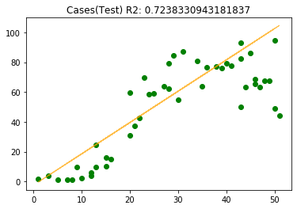

```python
drawLine(model, x_test, y_test, "Cases(Test)", score)
```

```
Cases(Test,Delta Day Zero) R2: 0.7503970891830353
Intercept(s):  [-0.56171158]
```

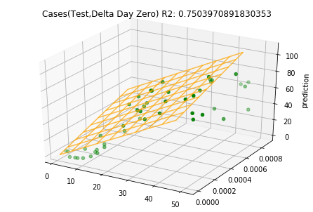

```python
drawPlane(model_d, x_test_d, y_test_d, "Cases(Test,Delta Day Zero)", score_d)
```

```
The model performance for the test set
-------------------------------------------
RMSE of test set is 12.666871848705176
R2 score of test set is 0.8264084748378203
```

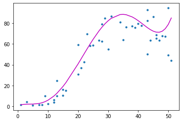

```python
x_train, x_test, y_train, y_test = train_test_split(x_f, y_f, test_size= 0.3, random_state = 7)
poly_model, poly_features, y_test_predict, score, X_test, Y_test = polyRegression(x_train, x_test, y_train, y_test)

plt.scatter(X_test, Y_test, s=10)
plt.plot(X_test, y_test_predict, color='m')
plt.show()
```

```
The model performance for the test set
-------------------------------------------
RMSE of test set is 11.890215656455402
R2 score of test set is 0.8727061351999738
Cases(Delta day, zero, Test) R2 Train: 0.9210488763758374
Intercept(s):  [-1.66969137]
```

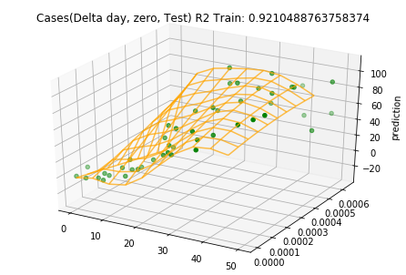

```python
x_train, x_test, y_train, y_test = train_test_split(x_f_d, y_f, test_size= 0.3, random_state = 10)
poly_model, poly_features, y_test_predict, score, x_test, y_test = polyRegression(x_train, x_test, y_train, y_test)
drawPolyPlane(poly_model, poly_features , x_test, y_test, "Cases(Delta day, zero, Test)", score)
```